# 06 · Proyecto: Organizador inteligente de documentos

## Proyecto: Organizador inteligente de documentos

06 · PROYECTO INTEGRADOR · BLOQUES 01–05

Organizador inteligente  
de documentos

**Construcción guiada de la mesa de entrada de un observatorio**

De una bandeja desordenada a un archivo explicable y recuperable.

Datos de aula completamente ficticios.

## El encargo: ordenar sin perder el criterio

El observatorio recibe datos, informes y actas de varios equipos. Hay entregas repetidas, fechas imposibles y versiones incompatibles.

**Construiremos una herramienta que clasifica lo justificable y deja evidencia de lo que necesita una decisión humana.**

## Qué habremos construido al terminar

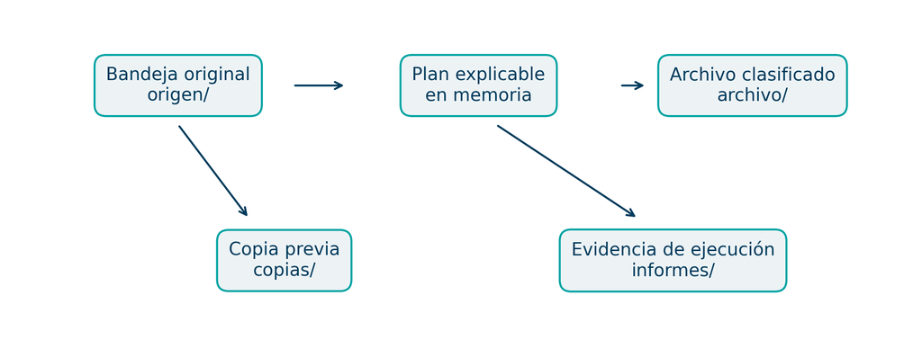

## Dónde aplicamos cada bloque

| Bloque previo | Pieza del proyecto |
| --- | --- |
| 01 · Automatización | Entrada, decisión, acción y evidencia. |
| 02 · Detectar procesos | Alcance, excepciones y retorno esperado. |
| 03 · pathlib | Rutas, recorrido y destinos. |
| 04 · Lotes y programación | Estados, repetición, CLI y planificador. |
| 05 · Copias de seguridad | Generación previa, hashes y restauración. |

## Una mejora que podamos justificar

120 documentos al mes, 45 s por documento, 20 % requiere revisión. Bajo estas hipótesis:

$$Ahorro=120\times0{,}80\times45/60=72\ min/mes$$

90 min de construcción / 72 min ahorrados ≈ **1,25 meses**.

## Decisiones de alcance antes de programar

Clasificamos por **nombre, fecha, tipo y sufijo**. No interpretamos el significado del documento.

Conservamos la bandeja original. No sobrescribimos el archivo. Las ambigüedades se describen en un informe; no se trasladan a una papelera.

## Contrato de nombres

`2026-10-02_informe_DOC-002.md`

| Parte | Regla |
| --- | --- |
| Fecha | AAAA-MM-DD y fecha real de calendario. |
| Tipo | datos, informe, contexto o acta. |
| ID | DOC- seguido de tres cifras. |
| Sufijo | Compatible con el tipo declarado. |

## El resultado esperado de la demo

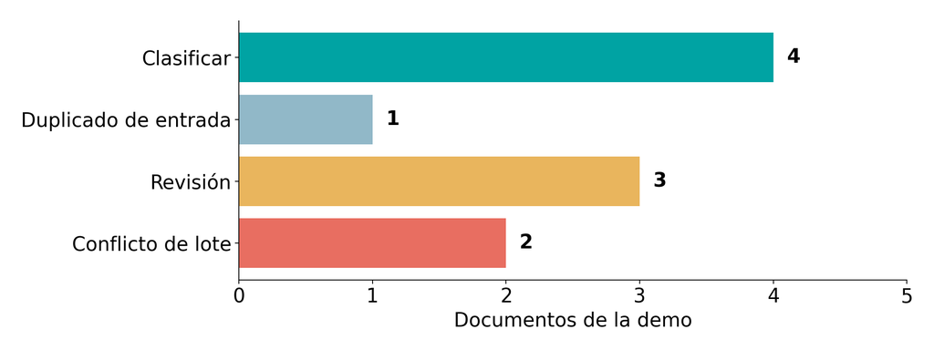

## Cómo seguir el tutorial

Trabaja en `script_alumnado.py` y guarda avances. Compara tu versión con `etapas/01_demo.py` a `08_cli.py`.

Cada paso incluye **propósito → código → ejecución → resultado esperado**. Al terminar utiliza `organizador.py` como referencia integrada.

## Preparación: requisitos y terminal

Python **3.11+**, biblioteca estándar y carpeta del paquete extraída. Jupyter es opcional para los notebooks.

Abre una terminal en la carpeta del bloque. En los comandos siguientes, `python` debe identificar tu intérprete. En Windows puede ser necesario usar `py -3.11`.

## Paso 00 · Verificar el punto de partida

```bash
python --version
python organizador.py --help
```

**Comprobar:** Versión compatible y tres subcomandos: crear-demo, plan y ejecutar.

## Carpetas y responsabilidades

| Ruta dentro de demo/ | Responsabilidad |
| --- | --- |
| origen/ | Bandeja sintética que conservamos. |
| archivo/ | Copias clasificadas por tipo/año/mes. |
| informes/ | Evidencia JSON de cada aplicación. |
| copias/ y restauraciones/ | Motor de recuperación del bloque 05. |
| estado/ y reglas.json | Bloqueos y configuración. |

## Paso 01 · Importaciones que ya conoces

```python
from pathlib import Path, PurePosixPath
from collections import Counter, defaultdict
from datetime import date, datetime, timezone
import argparse, json, logging, re, sys, uuid
import copias_seguridad as backup
```

`Path` opera en el sistema. `PurePosixPath` representa rutas del contrato.

## La configuración es un dato versionado

```json
{
  "schema": 1,
  "tipos": {
    "informe": {"sufijo": ".md", "carpeta": "informes"},
    "datos": {"sufijo": ".csv", "carpeta": "datos"}
  }
}
```

La demo incluye además contexto y acta.

## Construir crear_demo · 1/3

Crear una raíz nueva y diez documentos ficticios.

```python
def crear_demo(destino):
    """Etapa 01. Crear únicamente una raíz nueva con datos ficticios."""
    raiz = Path(destino).absolute()
    raiz.mkdir(parents=True, exist_ok=False, mode=0o700)
    for nombre in ("origen", "archivo", "informes", "copias", "restauraciones", "estado"):
        (raiz / nombre).mkdir()
    marca = {"tipo": "demo_copias", "schema": 1, "id": uuid.uuid4().hex}
    (raiz / "proyecto_backup.json").write_text(json.dumps(marca), encoding="utf-8")
    (raiz / "organizador.json").write_text(
        '{"schema":1,"tipo":"observatorio_aula"}', encoding="utf-8"
    )
    (raiz / "reglas.json").write_text(json.dumps(REGLAS, indent=2), encoding="utf-8")
    textos = {
```

## Construir crear_demo · 2/3

Crear una raíz nueva y diez documentos ficticios.

```python
        "equipo_a/2026-10-01_datos_DOC-001.csv": "id;importe\nDEMO-001;1200000\n",
        "equipo_b/2026-10-01_datos_DOC-001.csv": "id;importe\nDEMO-001;1200000\n",
        "2026-10-02_informe_DOC-002.md": "# Informe ficticio\nSolo datos de aula.\n",
        "2026-10-03_contexto_DOC-003.json": '{"territorio":"DEMO"}\n',
        "2026-10-04_acta_DOC-004.txt": "Acta ficticia del observatorio.\n",
        "sin_fecha.txt": "Pendiente de identificar.\n",
        "2026-02-30_informe_DOC-005.md": "Fecha imposible.\n",
        "2026-10-06_informe_DOC-006.txt": "Tipo y extension incompatibles.\n",
        "area_a/2026-10-07_informe_DOC-007.md": "Version A\n",
        "area_b/2026-10-07_informe_DOC-007.md": "Version B\n",
    }
    for relativa, texto in textos.items():
        p = raiz / "origen" / relativa
```

## Construir crear_demo · 3/3

Crear una raíz nueva y diez documentos ficticios.

```python
        p.parent.mkdir(parents=True, exist_ok=True)
        with p.open("x", encoding="utf-8", newline="\n") as f:
            f.write(texto)
    return raiz
```

## Control 01 · Crear la mesa de entrada

```bash
python etapas/01_demo.py crear-demo demo
```

**Comprobar:** Diez archivos dentro de origen/; archivo/, copias/ e informes/ vacíos.

## Paso 02 · Validar antes de interpretar

Un JSON puede ser sintácticamente correcto y contener una regla peligrosa o incompatible.

Limitamos tamaño, rechazamos enlaces y exigimos campos y tipos previstos.

## Construir leer_json

Leer JSON de control acotado y estricto.

```python
def leer_json(ruta):
    """Etapa 02. Lectura acotada de un archivo real, sin enlaces."""
    if ruta.is_symlink() or not ruta.is_file():
        raise backup.ContratoError("Se requiere un JSON regular")
    with ruta.open("rb") as f:
        datos = f.read(65537)
    if len(datos) > 65536:
        raise backup.ContratoError("JSON de control demasiado grande")
    try:
        return backup.json_estricto(datos.decode("utf-8"))
    except (ValueError, UnicodeError) as error:
        raise backup.ContratoError("JSON de control inválido") from error
```

## Construir cargar_proyecto

Comprobar el proyecto y sus carpetas.

```python
def cargar_proyecto(proyecto):
    raiz = backup.cargar_proyecto(proyecto)
    if leer_json(raiz / "organizador.json") != {"schema": 1, "tipo": "observatorio_aula"}:
        raise backup.ContratoError("No se reconoce el organizador de aula")
    for nombre in ("archivo", "informes"):
        p = raiz / nombre
        if p.is_symlink() or not p.is_dir():
            raise backup.ContratoError("Falta una carpeta real: " + nombre)
    return raiz
```

## Construir cargar_reglas · 1/2

Validar la versión y cada regla.

```python
def cargar_reglas(raiz):
    reglas = leer_json(raiz / "reglas.json")
    if not isinstance(reglas, dict) or set(reglas) != {"schema", "tipos"}:
        raise backup.ContratoError("Campos de reglas incompatibles")
    if type(reglas["schema"]) is not int or reglas["schema"] != 1:
        raise backup.ContratoError("Versión de reglas incompatible")
    tipos = reglas["tipos"]
    if not isinstance(tipos, dict) or not 1 <= len(tipos) <= 20:
        raise backup.ContratoError("Se requieren entre 1 y 20 tipos")
    for tipo, regla in tipos.items():
        if not re.fullmatch(r"[a-z]+", tipo) or not isinstance(regla, dict):
            raise backup.ContratoError("Tipo o regla incompatible")
        if set(regla) != {"sufijo", "carpeta"}:
```

## Construir cargar_reglas · 2/2

Validar la versión y cada regla.

```python
            raise backup.ContratoError("Campos de una regla incompatibles")
        sufijo = regla["sufijo"]
        if not isinstance(sufijo, str) or not re.fullmatch(r"\.[a-z]+", sufijo):
            raise backup.ContratoError("Sufijo incompatible")
        backup.nombre_simple(regla["carpeta"])
    return reglas
```

## Control 02 · Inspeccionar sin cambiar archivos

```bash
python etapas/02_configuracion.py inspeccionar demo
```

**Comprobar:** schema 1 y cuatro tipos válidos. Ningún archivo clasificado ni copia creada.

## Paso 03 · Clasificar es proponer un destino

`2026-10-02_informe_DOC-002.md`

→ `informes/2026/10/2026-10-02_informe_DOC-002.md`

La función devuelve un destino o un motivo de revisión. **No copia archivos.**

## Forma y significado de la fecha

```python
PATRON = (
    r"(?P<fecha>\d{4}-\d{2}-\d{2})_(?P<tipo>[a-z]+)_"
    r"(?P<id>DOC-\d{3})(?P<sufijo>\.[a-z]+)"
)
```

La forma admite `2026-02-30`; el calendario la rechaza.

## Construir clasificar · 1/2

Proponer una ruta o describir por qué se revisa.

```python
def clasificar(relativa, reglas):
    """Etapa 03. Una decisión explícita, sin adivinar el contenido."""
    nombre = backup.ruta_relativa_segura(relativa).name
    m = re.fullmatch(PATRON, nombre, flags=re.ASCII)
    if m is None:
        return {"motivo": "nombre_fuera_de_contrato"}
    try:
        fecha = date.fromisoformat(m["fecha"])
    except ValueError:
        return {"motivo": "fecha_invalida"}
    regla = reglas["tipos"].get(m["tipo"])
    if regla is None:
        return {"motivo": "tipo_sin_regla"}
```

## Construir clasificar · 2/2

Proponer una ruta o describir por qué se revisa.

```python
    if m["sufijo"] != regla["sufijo"]:
        return {"motivo": "sufijo_incompatible"}
    destino = PurePosixPath(
        regla["carpeta"], str(fecha.year), f"{fecha.month:02d}", nombre
    )
    backup.ruta_relativa_segura(destino.as_posix())
    return {"destino": destino.as_posix(), "motivo": "regla_de_nombre"}
```

## Control 03 · Probar una decisión

```bash
python etapas/03_clasificacion.py clasificar demo \
  --nombre 2026-02-30_informe_DOC-005.md
```

**Comprobar:** motivo = fecha_invalida. Probar también un nombre correcto y observar destino.

## Paso 04 · De un archivo a un lote

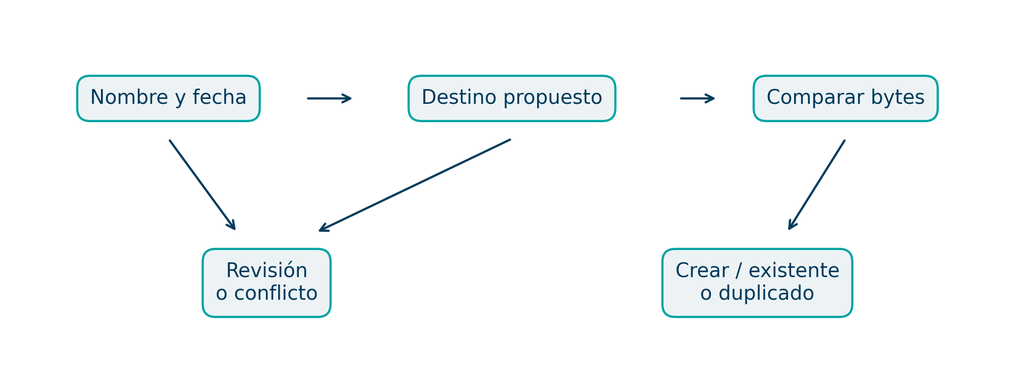

## Mismo destino no significa mismo contenido

| Situación | Decisión |
| --- | --- |
| Un destino propuesto y ausente | crear |
| Varias entradas, misma huella | Representante + duplicado_lote. |
| Varias entradas, distinta huella | conflicto_lote para todas. |
| Destino existente e idéntico | existente |
| Destino existente y diferente | conflicto_destino |

## Construir resolver_destino · 1/2

Rechazar enlaces y colisiones en componentes del destino.

```python
def resolver_destino(raiz, relativa):
    """Etapa 04. Ningún componente existente del destino puede ser enlace."""
    partes = backup.ruta_relativa_segura(relativa).parts
    actual = raiz / "archivo"
    for i, parte in enumerate(partes):
        actual = actual / parte
        if actual.parent.exists() and any(
            p.name.casefold() == parte.casefold() and p.name != parte
            for p in actual.parent.iterdir()
        ):
            raise backup.ContratoError("Colisión de mayúsculas en destino")
        if actual.is_symlink():
            raise backup.ContratoError("Enlace en destino")
```

## Construir resolver_destino · 2/2

Rechazar enlaces y colisiones en componentes del destino.

```python
        if actual.exists() and i < len(partes) - 1 and not actual.is_dir():
            raise backup.ContratoError("Un archivo ocupa una carpeta de destino")
        if actual.exists() and i == len(partes) - 1 and not actual.is_file():
            raise backup.ContratoError("Destino existente no regular")
    return actual
```

## Construir planificar · 1/3

Inventariar, clasificar, agrupar y reconciliar destinos.

```python
def planificar(proyecto):
    """Un plan nuevo refleja el estado actual; no autoriza una ejecución futura."""
    raiz = cargar_proyecto(proyecto)
    reglas = cargar_reglas(raiz)
    filas = []
    for entrada in backup.inventariar(raiz / "origen"):
        fila = dict(entrada)
        fila.update(clasificar(entrada["ruta"], reglas))
        fila["estado"] = "candidato" if "destino" in fila else "revision"
        filas.append(fila)
    grupos = defaultdict(list)
    for fila in filas:
        if fila["estado"] == "candidato":
```

## Construir planificar · 2/3

Inventariar, clasificar, agrupar y reconciliar destinos.

```python
            grupos[fila["destino"].casefold()].append(fila)
    for grupo in grupos.values():
        if len({f["sha256"] for f in grupo}) > 1:
            for fila in grupo:
                fila.update(
                    estado="conflicto_lote", motivo="mismo_destino_bytes_distintos"
                )
            continue
        primera = grupo[0]
        destino = resolver_destino(raiz, primera["destino"])
        if not destino.exists():
            primera["estado"] = "crear"
        else:
```

## Construir planificar · 3/3

Inventariar, clasificar, agrupar y reconciliar destinos.

```python
            n, h = backup.hash_archivo(destino)
            coincide = (n, h) == (primera["bytes"], primera["sha256"])
            primera["estado"] = "existente" if coincide else "conflicto_destino"
        for repetida in grupo[1:]:
            repetida.update(estado="duplicado_lote", motivo="mismo_destino_y_bytes",
                           representante=primera["ruta"])
    return {"schema": 1, "proyecto": str(raiz), "reglas": reglas,
            "filas": filas, "conteo": dict(Counter(f["estado"] for f in filas))}
```

## Control 04 · Revisar las diez decisiones

```bash
python etapas/04_plan.py plan demo
```

**Comprobar:** La suma de los conteos es 10. Cada fila incluye ruta, bytes, SHA-256, estado y motivo.

## Una suma que siempre debe cuadrar

$$N=\sum_{s\in estados}n_s$$

Primera simulación: **10 = 4 + 1 + 3 + 2**.

Si no cuadra, hay entradas sin decisión o estados contados dos veces.

## Paso 05 · Una simulación que no publica

La simulación calcula el plan y lo devuelve por stdout. No crea archivos de salida, informes ni copias de seguridad.

Al aplicar se recalcula el plan: la simulación anterior no reserva el estado del disco.

## Construir resumen_plan

Marcar explícitamente la simulación y devolver su evidencia.

```python
def resumen_plan(proyecto):
    """Etapa 05. La simulación completa no escribe un informe en disco."""
    plan = planificar(proyecto)
    return {"accion": "plan", "aplicado": False, **plan}
```

## Control 05 · Primer ensayo completo

```bash
python organizador.py plan --proyecto demo
python organizador.py ejecutar --proyecto demo
```

**Comprobar:** Ambas órdenes simulan. No aparece ninguna generación en copias/.

## Paso 06 · Copiar y contrastar una salida

Primero se escribe un parcial exclusivo junto al destino. Se contrasta tamaño y SHA-256. Solo entonces se publica el nombre final.

El origen permanece intacto.

## Construir copiar_documento

Publicar un archivo solo después del contraste.

```python
def copiar_documento(raiz, fila):
    """Etapa 06. Publicación por archivo, nunca sobrescritura deliberada."""
    origen = (raiz / "origen").joinpath(*PurePosixPath(fila["ruta"]).parts)
    destino = resolver_destino(raiz, fila["destino"])
    destino.parent.mkdir(parents=True, exist_ok=True)
    parcial = destino.parent / (".parcial_" + uuid.uuid4().hex)
    backup.copiar_contraste(origen, parcial, fila)
    if backup.hash_archivo(parcial) != (fila["bytes"], fila["sha256"]):
        raise backup.IntegridadError("Fallo de contraste del parcial")
    if destino.exists() or destino.is_symlink():
        raise backup.ContratoError("El destino apareció; no se publica")
    parcial.rename(destino)
    return "creado"
```

## Control 06 · Ensayo aislado de la función

```python
with TemporaryDirectory() as t:
    p = crear_demo(Path(t) / "demo")
    fila = next(f for f in planificar(p)["filas"]
                if f["estado"] == "crear")
    assert copiar_documento(p, fila) == "creado"
    assert (p / "origen" / fila["ruta"]).is_file()
```

## Paso 07 · Una ejecución protegida

Adquirir bloqueo del organizador. Recalcular plan. Si hay salidas nuevas, crear y verificar una copia de **toda la bandeja**.

Solo después publicar archivos y escribir un informe por ejecución.

## Dos bloqueos y un orden fijo

El organizador usa `estado/organizador.lock`; el motor del bloque 05 usa `estado/copias.lock`.

El organizador puede llamar al motor de copias mientras conserva su propio bloqueo. **No adquiere dos veces el mismo lock.**

## Construir ejecutar · 1/4

Aplicar el plan, registrar resultados y retirar solo el bloqueo propio.

```python
def ejecutar(proyecto, aplicar=False):
    """Etapa 07. Bloqueo de organizador -> backup con su bloqueo -> publicación."""
    if type(aplicar) is not bool:
        raise backup.ContratoError("aplicar debe ser booleano")
    if not aplicar:
        return resumen_plan(proyecto)
    raiz = cargar_proyecto(proyecto)
    lock = raiz / "estado" / "organizador.lock"
    token = uuid.uuid4().hex
    try:
        with lock.open("x", encoding="utf-8") as f:
            f.write(token)
    except FileExistsError as error:
```

## Construir ejecutar · 2/4

Aplicar el plan, registrar resultados y retirar solo el bloqueo propio.

```python
        raise backup.BloqueoOcupado("Organizador ocupado") from error
    try:
        plan = planificar(raiz)
        generacion = None
        if plan["conteo"].get("crear", 0):
            generacion = backup.crear_copia(raiz, aplicar=True)["copia"]
        for fila in plan["filas"]:
            if fila["estado"] == "crear":
                try:
                    fila["estado"] = copiar_documento(raiz, fila)
                except (OSError, ValueError) as error:
                    fila.update(estado="error_operativo", motivo=type(error).__name__)
        conteo = dict(Counter(f["estado"] for f in plan["filas"]))
```

## Construir ejecutar · 3/4

Aplicar el plan, registrar resultados y retirar solo el bloqueo propio.

```python
        pendientes = ("revision", "conflicto_lote", "conflicto_destino")
        incidencias = any(conteo.get(k, 0) for k in pendientes)
        codigo = 30 if conteo.get("error_operativo", 0) else 10 if incidencias else 0
        informe = {**plan, "accion": "ejecutar", "aplicado": True,
                   "conteo": conteo, "codigo": codigo, "copia_previa": generacion,
                   "fecha_utc": datetime.now(timezone.utc).isoformat()}
        nombre = "ejecucion_" + uuid.uuid4().hex + ".json"
        informe["informe"] = nombre
        with (raiz / "informes" / nombre).open("x", encoding="utf-8") as f:
            json.dump(informe, f, ensure_ascii=False, indent=2)
        return informe
    finally:
        if (lock.is_file() and not lock.is_symlink()
```

## Construir ejecutar · 4/4

Aplicar el plan, registrar resultados y retirar solo el bloqueo propio.

```python
                and lock.read_text(encoding="utf-8") == token):
            lock.unlink()
```

## Control 07 · Primera aplicación

```bash
python etapas/07_ejecucion.py ejecutar demo --aplicar
```

**Comprobar:** Cuatro salidas, una copia previa y un informe. Código 10 por revisiones y conflictos previstos.

## Qué debe contener el informe

Identidad de informe, fecha UTC, reglas utilizadas, copia previa, filas con motivo y conteos finales.

`crear` pasa a `creado` tras publicar. Un fallo local se registra como `error_operativo`.

## El lote no es una transacción única

Un fallo tras la segunda salida puede dejar dos archivos publicados. El informe puede fallar después.

No deshacemos automáticamente las publicaciones. Reconciliamos con el disco y repetimos de forma controlada.

## Paso 08 · Un contrato de CLI estable

| Acción | Efecto |
| --- | --- |
| crear-demo RUTA | Crea una demo nueva. |
| plan –proyecto RUTA | Simula y devuelve decisiones. |
| ejecutar –proyecto RUTA | También simula por defecto. |
| ejecutar … –aplicar | Crea copia previa, salidas e informe. |

## Construir main · 1/3

Exponer argumentos, JSON UTF-8 y categorías de salida.

```python
def main(argv=None):
    """Etapa 08. CLI independiente de cwd y sin preguntas interactivas."""
    for canal in (sys.stdout, sys.stderr):
        if hasattr(canal, "reconfigure"):
            canal.reconfigure(encoding="utf-8")
    parser = argparse.ArgumentParser(description=__doc__)
    sub = parser.add_subparsers(dest="accion", required=True)
    crear = sub.add_parser("crear-demo")
    crear.add_argument("destino", type=Path)
    for accion in ("plan", "ejecutar"):
        p = sub.add_parser(accion)
        p.add_argument("--proyecto", type=Path, required=True)
        if accion == "ejecutar":
```

## Construir main · 2/3

Exponer argumentos, JSON UTF-8 y categorías de salida.

```python
            p.add_argument("--aplicar", action="store_true")
    args = parser.parse_args(argv)
    logging.basicConfig(
        level=logging.INFO, format="%(asctime)s %(levelname)s %(message)s"
    )
    try:
        if args.accion == "crear-demo":
            resultado = {"proyecto": str(crear_demo(args.destino))}
        elif args.accion == "plan":
            resultado = resumen_plan(args.proyecto)
        else:
            resultado = ejecutar(args.proyecto, args.aplicar)
        print(json.dumps(resultado, ensure_ascii=False))
```

## Construir main · 3/3

Exponer argumentos, JSON UTF-8 y categorías de salida.

```python
        return resultado.get("codigo", 0)
    except backup.BloqueoOcupado:
        LOG.error("Bloqueo de copias ocupado")
        return 40
    except (backup.ContratoError, backup.IntegridadError, FileExistsError) as error:
        LOG.error("Contrato o integridad: %s", error)
        return 20
    except Exception:
        LOG.exception("Fallo operativo; revisar informe, parciales y archivo")
        return 30
```

## Últimas dos líneas del script

```python
if __name__ == "__main__":
    raise SystemExit(main())
```

Al importar funciones para probarlas, el CLI no arranca. Al ejecutar el archivo, su código llega al planificador.

## Códigos del organizador, no del backup

| Código | Qué hacer |
| --- | --- |
| 0 | Operación correcta; comprobar si fue simulación. |
| 10 | Lote aplicado con revisión o conflicto pendiente. |
| 20 | Contrato o integridad impiden operar. |
| 30 | Fallo operativo; revisar estado y parciales. |
| 40 | Bloqueo ocupado. |
| 2 | Sintaxis de argumentos incorrecta. |

## Paso 09 · Ejecutar otra vez

```bash
python organizador.py ejecutar --proyecto demo --aplicar
```

**Comprobar:** existente 4, duplicado_lote 1, revision 3 y conflicto_lote 2. No crece archivo/ ni se crea otra copia previa.

## Qué significa idempotencia en este caso

$$F(F(archivo,entrada),entrada)=F(archivo,entrada)$$

Si datos y reglas no cambian, repetir no duplica ni reemplaza las salidas clasificadas. Los informes de ejecución sí cambian.

## No confundir duplicados y contradicciones

[figure not shown]

## Paso 10 · Probar una recuperación real

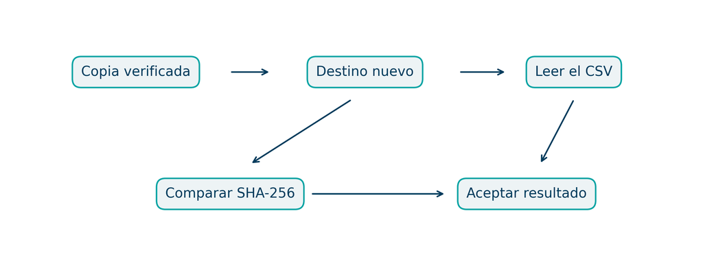

## Recuperar a partir del informe

```python
r = ejecutar(proyecto, aplicar=True)
id_copia = r["copia_previa"]
backup.verificar_copia(proyecto, id_copia)
backup.restaurar_copia(
    proyecto, id_copia, "ensayo_recuperacion", aplicar=True
)
```

El destino queda en `restauraciones/ensayo_recuperacion`.

## Validar el dato que recuperamos

```python
import csv
p = proyecto / "restauraciones/ensayo_recuperacion"
ruta = p / "equipo_a/2026-10-01_datos_DOC-001.csv"
with ruta.open(encoding="utf-8", newline="") as f:
    filas = list(csv.DictReader(f, delimiter=";"))
assert int(filas[0]["importe"]) == 1200000
```

## Retención como operación separada

```bash
python copias_seguridad.py retencion \
  --proyecto demo --conservar 2
```

Revisar primero. Aplicar después con `--aplicar`, tras comprobar una restauración y la política acordada.

## Paso 11 · Preparar la ejecución desatendida

Intérprete absoluto + script absoluto + proyecto absoluto. Registros separados de stdout y stderr. Política de solapamiento y responsable de revisión.

**Primero plan; después aplicación manual; finalmente programación.**

## Windows · Contrato de la tarea

| Campo | Valor que preparar |
| --- | --- |
| Programa | Ruta absoluta a python.exe. |
| Argumentos | Script absoluto, ejecutar, –proyecto y ruta absoluta. |
| Aplicación real | Añadir –aplicar tras el ensayo. |
| Inicio y cuenta | Carpeta del código y cuenta probada. |
| Solapamiento | No iniciar otra instancia; lock como refuerzo. |

## macOS y Linux · Misma aplicación, otro lanzador

| Sistema | Lanzador de referencia |
| --- | --- |
| macOS | launchd: ProgramArguments con cada argumento separado. |
| Linux | cron con rutas absolutas y redirecciones. |
| Linux con systemd | Service + timer; revisar resultado del servicio. |

Un código 10 merece revisión documental, no un reintento ciego.

## Pausa deliberada: criterios antes de programar

El plan cuadra; la aplicación produce cuatro salidas; repetir conserva las salidas; la recuperación funciona; se entienden las incidencias.

Solo entonces tiene sentido decidir **cuándo** arrancar el proceso.

## Paso 12 · Entregar un proyecto mantenible

Código, reglas, datos ficticios, instrucciones de ejecución, pruebas, informe de muestra y procedimiento de recuperación.

Explica qué decisiones automatizas y cuáles conservan intervención humana.

## Comprobar la solución completa

```bash
python comprobaciones_proyecto.py
python script_solucion.py --help
```

Las pruebas usan contenedores temporales propios: no cambian tu demo ni registran tareas.

## Reto 01 · Añadir contratos sin ocultar dudas

Añadir tipo `resumen` con sufijo `.txt` y carpeta `resumenes`.

Crear un documento correcto en una demo nueva, simular y explicar qué regla lo clasifica. Añadir un caso con sufijo incorrecto.

## Reto 02 · Investigar un conflicto de destino

En otra demo, alterar una salida ya archivada. Volver a simular.

¿Debe reemplazarse por el original automáticamente? ¿Qué evidencia pedirías para decidir?

## Reto 03 · Diseñar el siguiente incremento

Elegir una ampliación: informe más legible, revisión humana documentada o nuevos criterios de clasificación.

Definir entrada, decisión, excepciones, aceptación y recuperación antes de programarla.

## Evaluación del proyecto

| Dimensión | Evidencia |
| --- | --- |
| Diseño | Alcance, excepciones y valor estimado. |
| Construcción | Funciones separadas y rutas validadas. |
| Operación | Simulación, repetición, CLI e incidencias. |
| Recuperación | Copia previa, restauración y lectura útil. |
| Comunicación | Otra persona puede reproducir el recorrido. |

## Límites que acompañan al proyecto

Árbol local privado, estable y con origen en reposo. Sin cifrado ni autenticidad del manifiesto. Sin ACL ni metadatos completos.

Los parciales pueden quedar tras un fallo. No hay transacción global ni defensa contra un escritor hostil concurrente.

## Fuentes y continuidad del curso

[Python 3.11: pathlib](https://docs.python.org/3.11/library/pathlib.html), [re](https://docs.python.org/3.11/library/re.html), [argparse](https://docs.python.org/3.11/library/argparse.html) y [subprocess](https://docs.python.org/3.11/library/subprocess.html).

Motor y conceptos de los bloques 03–05. Próximo bloque: Excel con openpyxl (I).